# R Notebook for Pease Replication 2015 PID

# Load libraries

```r
#install.packages("haven")
#install.packages("olsrr")
#install.packages("descriptr")
#install.packages("modelr")
#install.packages("tidyverse")
#install.packages("mosaic")
#install.packages("GGally")
#install.packages("psych")
library("tidyverse")
library("haven")
library(olsrr)
library(descriptr)
library(modelr)
library(tidyverse)
library(mosaic)
library(GGally)
library(psych)
```

# Read in the original datafiles

```r
# to print this chunk, but not execute it again once the files are imported, add: eval=FALSE
# use the haven package to read in the data -- we need the MIDUS II data and the biomarker project data
#midus2 <- read_spss("04652-0001-Data.sav")
#bio <- read_spss("29282-0001-Data.sav")
#saveRDS(midus2, "midus2.rds")
#saveRDS(bio, "bio.rds")
```

# Read in the saved datafiles

```r
midus2 <- readRDS("midus2.rds")
bio <- readRDS("bio.rds")
```

# Subset the datafiles

```r
#CREATE AND FILTER MIDUS2 DATASET
midus2.subset <- midus2 %>%
  filter(SAMPLMAJ == 1) %>%
  select(M2ID,
         B1PRSEX,
         B1PF7A,
         contains("B1SE6"),
         B1PAGE_M2,
         B1SE7I,
         B1SE7T,
         B1SE7BB,
         B1SE7EE,
         B1SNEURO,
         B1SEXTRA,
         B1SOPEN,
         B1SCONS2,
         B1SAGREE,
         B1SMPQAG) %>%
  filter(complete.cases(B1SNEURO,
                        B1SEXTRA,
                        B1SOPEN,
                        B1SCONS2,
                        B1SAGREE,
                        B1SMPQAG,
                        B1PRSEX,
                        B1PAGE_M2,
                        B1PF7A
                        )) %>%
  mutate(IN_MIDUS2 = 1)
#CREATE AND FILTER BIO SUBSET
bio.subset <- bio %>%
  select(M2ID,
         contains("B4Q4"),
         contains("B4Q5"),
         contains("B4Q6"),
         B4QTA_AG,
         B4QTA_AT,
         B4QTA_AR,
         B4QAE_AI,
         B4QAE_AO,
         B4QAE_AC,
         B4QAE_AA) %>%
  filter(complete.cases(B4QTA_AG,
                        B4QTA_AT,
                        B4QTA_AR,
                        B4QAE_AI,
                        B4QAE_AO,
                        B4QAE_AC,
                        B4QAE_AA)) %>%
  mutate(IN_BIO = 1)
combine <- left_join(midus2.subset, bio.subset, by = "M2ID") %>%
  select(M2ID,
         B1PF7A,
         B1SNEURO,
         B1SAGREE,
         B1SEXTRA,
         B1SOPEN,
         B1SCONS2,
         B4QTA_AG,
         B4QTA_AT,
         B4QTA_AR,
         B4QAE_AI,
         B4QAE_AO,
         B4QAE_AC,
         B4QAE_AA,
         B1SMPQAG,
         B1PF7A,
         B1PAGE_M2,
         B1PRSEX,
         everything())
combine
```

| M2ID | B1PF7A | B1SNEURO | B1SAGREE | B1SEXTRA | B1SOPEN | B1SCONS2 | B4QTA_AG | B4QTA_AT | B4QTA_AR | B4QAE_AI | B4QAE_AO | B4QAE_AC | B4QAE_AA | B1SMPQAG | B1PAGE_M2 | B1PRSEX | B1SE6A | B1SE6B | B1SE6C | B1SE6D | B1SE6E | B1SE6F | B1SE6G | B1SE6H | B1SE6I | B1SE6J | B1SE6K | B1SE6L | B1SE6M | … |
| --- | --- | --- | --- | --- | --- | --- | --- | --- | --- | --- | --- | --- | --- | --- | --- | --- | --- | --- | --- | --- | --- | --- | --- | --- | --- | --- | --- | --- | --- | --- |
| 10002 | 1 | 2.000 | 3.40 | 2.600 | 2.143 | 2.800 | 21.0 | 4.0 | 6.0 | 13.0 | 13.0 | 10.0 | 2.0 | 4.000 | 69 | 1 | 3 | 2 | 3 | 3 | 2 | 2 | 2 | 3 | 1 | 1 | 2 | 1 | 4 | … |
| 10019 | 1 | 1.500 | 3.60 | 3.400 | 3.143 | 3.000 | 26.0 | 4.0 | 11.0 | 17.0 | 12.0 | 12.0 | 2.0 | 5.000 | 51 | 1 | 1 | 1 | 3 | 3 | 1 | 1 | 1 | 4 | 2 | 3 | 3 | 1 | 4 | … |
| 10023 | 1 | 1.750 | 4.00 | 3.600 | 3.571 | 3.400 | NA | NA | NA | NA | NA | NA | NA | 4.000 | 78 | 2 | 1 | 1 | 4 | 2 | 2 | 1 | 1 | 3 | 1 | 3 | 2 | 1 | 3 | … |
| 10039 | 8 | 1.750 | 3.80 | 3.000 | 3.571 | 3.200 | NA | NA | NA | NA | NA | NA | NA | 5.000 | 53 | 1 | 2 | 2 | 4 | 3 | 1 | 1 | 1 | 3 | 1 | 3 | 2 | 1 | 4 | … |
| 10040 | 1 | 3.000 | 3.00 | 3.200 | 3.429 | 3.600 | 20.0 | 4.0 | 6.0 | 12.0 | 9.0 | 13.0 | 2.0 | 8.000 | 49 | 1 | 2 | 1 | 1 | 2 | 1 | 1 | 2 | 1 | 1 | 3 | 3 | 2 | 3 | … |
| 10042 | 1 | 1.750 | 4.00 | 3.200 | 3.714 | 4.000 | NA | NA | NA | NA | NA | NA | NA | 8.000 | 59 | 2 | 2 | 1 | 3 | 1 | 1 | 2 | 1 | 3 | 1 | 2 | 2 | 1 | 4 | … |
| 10047 | 1 | 1.750 | 4.00 | 3.000 | 2.429 | 4.000 | 27.0 | 7.0 | 8.0 | 16.0 | 16.0 | 9.0 | 2.0 | 9.000 | 45 | 2 | 2 | 1 | 3 | 1 | 2 | 2 | 1 | 3 | 1 | 2 | 2 | 1 | 4 | … |
| 10050 | 1 | 3.000 | 4.00 | 2.800 | 3.714 | 3.600 | NA | NA | NA | NA | NA | NA | NA | 4.000 | 44 | 2 | 3 | 1 | 1 | 1 | 1 | 1 | 1 | 2 | 1 | 1 | 2 | 1 | 2 | … |
| 10060 | 1 | 2.250 | 3.60 | 3.000 | 3.714 | 3.000 | 24.0 | 4.0 | 8.0 | 15.0 | 10.0 | 13.0 | 3.0 | 6.000 | 58 | 1 | 3 | 1 | 3 | 2 | 1 | 1 | 1 | 3 | 1 | 3 | 3 | 2 | 3 | … |
| 10061 | 1 | 1.750 | 3.20 | 2.400 | 3.000 | 3.600 | 22.0 | 5.0 | 8.0 | 18.0 | 12.0 | 12.0 | 2.5 | 7.000 | 81 | 1 | 3 | 1 | 4 | 2 | 1 | 2 | 3 | 3 | 1 | 2 | 3 | 1 | 3 | … |

[output cut: 990 more lines]

# create dataset for analysis

```r
# note which variables are categorical and numeric and tidy things up
analyze <- combine
all.vars <- names(analyze)
cat.vars <- c("M2ID", "B1PF7A")
##Note this needs o be done because we originally read in data from spss files, r doesn't like the spss files.
analyze <- analyze %>%
  mutate_at(vars(all.vars), funs(as.numeric)) %>%
  mutate_at(vars(cat.vars), funs(as.factor)) %>%
  mutate(GENDER = factor(B1PRSEX, levels = c("1", "2"), labels = c("male", "female"))) %>%
  mutate(MALE = B1PRSEX - 1) %>%
  select(-B1PRSEX)
# create subset of just variable scale scores and the demographic variables
analyze <- analyze %>%
  select(B1SNEURO, B1SAGREE, B1SEXTRA, B1SOPEN, B1SCONS2,
         B4QTA_AG, B4QTA_AT, B4QTA_AR, B4QAE_AI, B4QAE_AO, B4QAE_AC,
         B1SMPQAG,
         B1PF7A,
         B1PAGE_M2, B4QAE_AA,
         GENDER, MALE) %>%
  filter(complete.cases(B1SNEURO, B1SAGREE, B1SEXTRA, B1SOPEN, B1SCONS2,
         B4QAE_AA))
analyze
```

| B1SNEURO | B1SAGREE | B1SEXTRA | B1SOPEN | B1SCONS2 | B4QTA_AG | B4QTA_AT | B4QTA_AR | B4QAE_AI | B4QAE_AO | B4QAE_AC | B1SMPQAG | B1PF7A | B1PAGE_M2 | B4QAE_AA | GENDER | MALE |
| --- | --- | --- | --- | --- | --- | --- | --- | --- | --- | --- | --- | --- | --- | --- | --- | --- |
| 2.000 | 3.40 | 2.60 | 2.143 | 2.80 | 21.0 | 4.0 | 6.0 | 13.0 | 13.0 | 10.0 | 4.000 | 1 | 69 | 2.0 | male | 0 |
| 1.500 | 3.60 | 3.40 | 3.143 | 3.00 | 26.0 | 4.0 | 11.0 | 17.0 | 12.0 | 12.0 | 5.000 | 1 | 51 | 2.0 | male | 0 |
| 3.000 | 3.00 | 3.20 | 3.429 | 3.60 | 20.0 | 4.0 | 6.0 | 12.0 | 9.0 | 13.0 | 8.000 | 1 | 49 | 2.0 | male | 0 |
| 1.750 | 4.00 | 3.00 | 2.429 | 4.00 | 27.0 | 7.0 | 8.0 | 16.0 | 16.0 | 9.0 | 9.000 | 1 | 45 | 2.0 | female | 1 |
| 2.250 | 3.60 | 3.00 | 3.714 | 3.00 | 24.0 | 4.0 | 8.0 | 15.0 | 10.0 | 13.0 | 6.000 | 1 | 58 | 3.0 | male | 0 |
| 1.750 | 3.20 | 2.40 | 3.000 | 3.60 | 22.0 | 5.0 | 8.0 | 18.0 | 12.0 | 12.0 | 7.000 | 1 | 81 | 2.5 | male | 0 |
| 2.000 | 2.80 | 3.00 | 2.857 | 3.00 | 24.0 | 4.0 | 7.0 | 20.0 | 13.0 | 4.0 | 5.000 | 1 | 61 | 1.5 | female | 1 |
| 2.250 | 2.40 | 1.80 | 2.714 | 3.20 | 24.0 | 6.0 | 7.0 | 19.0 | 13.0 | 11.0 | 9.000 | 1 | 48 | 2.5 | male | 0 |
| 1.500 | 3.20 | 2.60 | 3.714 | 4.00 | 25.0 | 4.0 | 8.0 | 14.0 | 11.0 | 13.0 | 5.000 | 1 | 58 | 2.5 | male | 0 |
| 2.250 | 4.00 | 2.00 | 1.429 | 4.00 | 16.0 | 4.0 | 4.0 | 13.0 | 12.0 | 13.0 | 4.000 | 1 | 45 | 3.0 | female | 1 |

[output cut: 617 more lines]

# Explore simple linear regression and correlation

## Anger Expression Adjustment scale description

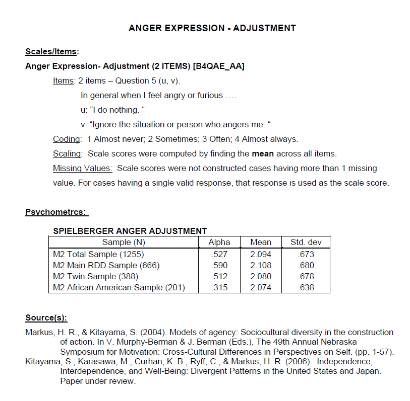

## Create a correlation matrix of Anger Expression Adjustment and the big 5 personality scales

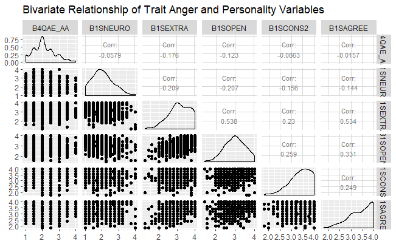

```r
scatterplot <- ggpairs(analyze,
                       columns = c("B4QAE_AA", "B1SNEURO", "B1SEXTRA", "B1SOPEN", "B1SCONS2", "B1SAGREE"),
                       upper = list(continuous = wrap("cor", size=3)),
        title = "Bivariate Relationship of Trait Anger and Personality Variables")
print(scatterplot, progress=FALSE )
```

We selected to look into Openess and its relationship with anger Expression adjustment based off of our its correlateion of -0.123 and our interest in how the two would relate.

Here are the descriptives fro opennesss from the *MIDUSII* codebook:

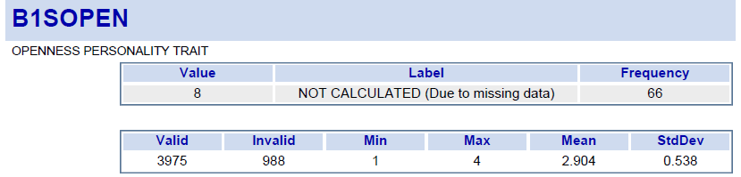

## Descriptive Statistics of predictor and outcome variables

### Anger Expression Adjustment (outcome)

```r
myvars <- analyze %>%
  select(B4QAE_AA, B1SOPEN) %>%
  na.omit()
summary_stats(myvars$B4QAE_AA)
```

```
                       Univariate Analysis

 N                     627.00      Variance                0.46
 Missing                 0.00      Std Deviation           0.68
 Mean                    2.10      Range                   3.00
 Median                  2.00      Interquartile Range     1.00
 Mode                    2.00      Uncorrected SS       3057.25
 Trimmed Mean            2.07      Corrected SS          288.82
 Skewness                0.51      Coeff Variation        32.33
 Kurtosis                0.09      Std Error Mean          0.03

                             Quantiles

             Quantile                            Value

            Max                                  4.00
            99%                                  4.00
            95%                                  3.00
            90%                                  3.50
            Q3                                   2.50
            Median                               2.00
            Q1                                   1.50
            10%                                  1.50
            5%                                   1.00
            1%                                   1.00
            Min                                  1.00

                           Extreme Values

                Low                              High

  Obs                       Value       Obs                       Value
  30                          1         17                          4
  37                          1         119                         4
  38                          1         125                         4
  70                          1         130                         4
  76                          1         142                         4
```

### Openness (Predictor)

```r
summary_stats(myvars$B1SOPEN)
```

```
                        Univariate Analysis

 N                      627.00      Variance                 0.27
 Missing                  0.00      Std Deviation            0.52
 Mean                     2.99      Range                    2.57
 Median                   3.00      Interquartile Range      0.86
 Mode                     3.00      Uncorrected SS        5766.27
 Trimmed Mean             3.00      Corrected SS           170.80
 Skewness                -0.18      Coeff Variation         17.49
 Kurtosis                -0.33      Std Error Mean           0.02

                              Quantiles

              Quantile                            Value

             Max                                   4.00
             99%                                   4.00
             95%                                   3.71
             90%                                   3.86
             Q3                                    3.43
             Median                                3.00
             Q1                                    2.57
             10%                                   2.29
             5%                                    2.14
             1%                                    1.71
             Min                                   1.43

                            Extreme Values

                Low                                High

  Obs                        Value       Obs                        Value
  10                         1.429       26                           4
  53                         1.571       62                           4
  173                        1.571       103                          4
  381                        1.571       111                          4
  401                        1.571       207                          4
```

## Set hypotheses

I am interested in assessing the relationship between Openness and ANGER EXPRESSION - ADJUSTMENT. In this case, I am not particularly interested in a significance test for the intercept, it’s the slope that is of interest. I will state a null and alternative hypothesis for the slope.

Ho: B1 = 0 Ha: B1 ne 0

## Set alpha and obtain the critical value of t

```r
qt(c(.025, .975), df=625)
```

```
[1] -1.963767  1.963767
```

## Center Openness at the mean and then fit the SLR

```r
#Centering opennes vatiable
myvars <- myvars %>%
  mutate(B1SOPEN_m = B1SOPEN - mean(B1SOPEN))
my_model <- lm(B4QAE_AA ~ B1SOPEN_m, data = myvars)

ols_regress(my_model)
```

```
                        Model Summary
--------------------------------------------------------------
R                       0.123       RMSE                0.675
R-Squared               0.015       Coef. Var          32.105
Adj. R-Squared          0.014       MSE                 0.455
Pred R-Squared          0.009       MAE                 0.525
--------------------------------------------------------------
 RMSE: Root Mean Square Error
 MSE: Mean Square Error
 MAE: Mean Absolute Error

                               ANOVA
-------------------------------------------------------------------
               Sum of
              Squares         DF    Mean Square      F        Sig.
-------------------------------------------------------------------
Regression      4.374          1          4.374    9.612    0.0020
Residual      284.445        625          0.455
Total         288.819        626
-------------------------------------------------------------------

                                  Parameter Estimates
----------------------------------------------------------------------------------------
      model      Beta    Std. Error    Std. Beta      t        Sig      lower     upper
----------------------------------------------------------------------------------------
(Intercept)     2.101         0.027                 77.993    0.000     2.048     2.154
  B1SOPEN_m    -0.160         0.052       -0.123    -3.100    0.002    -0.261    -0.059
----------------------------------------------------------------------------------------
```

### Interpretation

The intercept is 2.101, this is the predicted Anger Expression Adjustment score for individuals with an average level of openness. The slope is -0.160, this is the expected change in Anger Expression Adjustment for a one unit increase in Openness.

The estimate of the slope divided by the associated standard error gives t-star, that is t-star = -0.160/.052 =-3.100. This means that our estimate of the slope is -3.100 standard errors away from the asserted null hypothesis (0). If the null hypothesis were true, we would expect about 95% of the random samples to produce an estimate of the slope that is within 1.96 standard errors of 0. Therefore it is highly unlikely that the null hypothesis is true given this estimate of the slope. In fact, the p-value is .002, which provides the probability that we would obtain a t-star of this magnitude or larger if the null hypothesis were true. Therefore, we reject the null hypothesis.

### Create scatterplot of Openness and Anger Expression Adjustment with fitted model

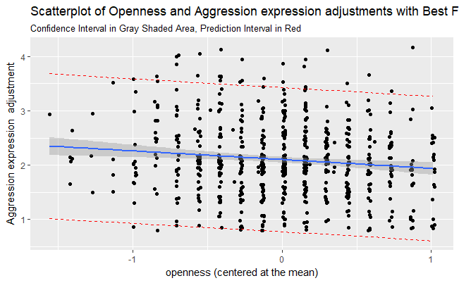

```r
temp_var <- predict(my_model, myvars, interval="prediction")
myvars_new <- cbind(temp_var, myvars)
ggplot(myvars_new, aes(x = B1SOPEN_m, y =B4QAE_AA)) +
  geom_jitter() +
  geom_smooth(method = "lm", se = TRUE) +
  geom_line(aes(y=lwr), color = "red", linetype = "dashed") +
  geom_line(aes(y=upr), color = "red", linetype = "dashed") +
  labs(title = "Scatterplot of Openness and Aggression expression adjustments with Best Fit Line",
       subtitle = "Confidence Interval in Gray Shaded Area, Prediction Interval in Red",
       x = "openness (centered at the mean)", y = "Aggression expression  adjustment")
```

### Residuals plot

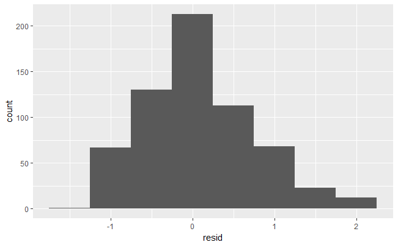

```r
myvars <- myvars %>%
  add_residuals(my_model)

ggplot(myvars, aes(x = resid)) + geom_histogram(binwidth = .5)
```

Our residual plot is relatively normally distributed.